# Chapter 13: Inference with Mathematical Models

# Overview

- 13 Inference with mathematical models
- 13.1 Central Limit Theorem
- 13.2 Normal Distribution
  - 13.2.1 Normal distribution model
  - 13.2.2 Standardizing with Z scores
  - 13.2.3 Normal probability calculations
  - 13.2.4 Normal probability examples
- 13.3 Quantifying the variability of a statistic
  - 13.3.1 68-95-99.7 rule
  - 13.3.2 Standard error
  - 13.3.3 Margin of error

# 13.1 Central Limit Theorem

## Sampling Distributions

- A *sampling distribution* is the distribution of all possible values of a sample statistic from samples of a given sample size from a given population.
- Think about the sampling distribution as describing as how sample statistics vary from one study to another.
- In Chapters 11 and 12, we simulated sampling distributions using card shuffling and bootstrapping.
  - Hypothesis Tests
  - Confidence Intervals

## Theory: Normal distribution

For large sample sizes, our simulated dotplots tend to look like:

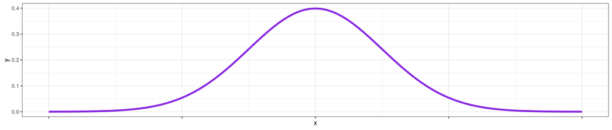

$$f(x) = \frac{1}{\sqrt{2\pi\sigma^2}} e^{-\frac{(x-\mu)^2}{2\sigma^2}},
\mbox{ mean} = \mu, \mbox{ SD} = \sigma$$

## Central Limit Theorem for proportions

**Theorem.** Suppose that $\hat{p}$ is a sample proportion calculated from a sample with *at least 10 successes and 10 failures* (i.e., at least 10 observations of each level). Then the sampling distribution of $\hat{p}$ is approximately normal.

## Group Activity

1. Suppose you have a spinner with two regions: SUCCESS and FAILURE. The probability of the spinner landing on SUCCESS is 0.6. You spin the spinner 100 times. Predict the most likely number of times the spinner lands on SUCCESS.

## One-Proportion Applet

https://www.rossmanchance.com/applets/2021/oneprop/OneProp.htm

## Group Activity (continued)

2. Open the [One Proportion Applet](https://www.rossmanchance.com/applets/2021/oneprop/OneProp.htm), set the *probability of heads/success* to 0.6, the *Sample size* to 100, and leave *Number of samples* at 1. Click *Draw Samples*. How close was the simulated sample from your prediction?
3. Click the radio button for *Proportion of successes*, set *Number of samples* to 10000, and click *Draw Samples*. Check the *Summary Statistics* box and record the Mean and Standard Deviation (SD) of the distribution.
4. Does the Central Limit Theorem apply? (i.e., are there enough expected successes and failures?) Check the *Normal Approximation* box and observe how well it fits.

## What if the CLT conditions don’t hold?

Suppose $n = 10$ and $\hat{p} = 0.9$. How good is the normal approximation? ([Applet](https://www.rossmanchance.com/applets/2021/oneprop/OneProp.htm))

# 13.2 Normal Distribution

## 13.2.1 Normal distribution model

- Given *parameters* $\mu$ and $\sigma$, the **Normal Distribution** with mean $\mu$ and standard deviation $\sigma$ is written $N(\mu, \sigma)$.
  - For example, the first distribution in the applet was $N(\mu = 0.6, \sigma = 0.049)$.
- $N(\mu, \sigma)$ is centered at the mean $\mu$.
- Most (i.e., about 95%) of $N(\mu, \sigma)$ lies in the interval $(\mu - 2\sigma, \mu + 2\sigma)$.
- See the [One Proportion Applet](https://www.rossmanchance.com/applets/2021/oneprop/OneProp.htm) again.

## 13.2.2 Standardizing with Z scores

- If an observation $x$ comes from $N(\mu, \sigma)$, it’s *Z-Score* is $Z = \frac{x-\mu}{\sigma}$.
- The Z-score is the number of standard deviations $x$ is above/below the mean.
  - Z-scores of $\pm 2$ are unusual.
  - Z-scores of $\pm 3$ are very unusual.
- Z-scores follow the *Standard Normal Distribution:* $N(\mu = 0, \sigma = 1)$.

## 13.2.3 Normal probability calculations

- We can compare observations from different normal distributions by computing Z-scores.

$$Z = \frac{x-\mu}{\sigma}$$

## Group Exercise

SAT scores follow a nearly normal distribution with a mean of 1500 points and a standard deviation of 300 points. ACT scores also follow a nearly normal distribution with mean of 21 points and a standard deviation of 5 points. Suppose Nel scored 1800 points on their SAT and Sian scored 24 points on their ACT.

1. Compute a Z-score for Nel.
2. Compute a Z-score for Sian.
3. Who performed better?

## 13.2.4 Normal probability examples

Nel’s percentile:

```r
pnorm(1)
```

```
[1] 0.8413447
```

Sian’s percentile:

```r
pnorm(0.6)
```

```
[1] 0.7257469
```

# 13.3 Quantifying the variability of a statistic

## 13.3.1 The 68-95-99.7 rule

- About 68% of $N(\mu,\sigma)$ lies within one standard deviation of the mean.
- About 95% of $N(\mu,\sigma)$ lies within two standard deviations of the mean.
- About 99.7% of $N(\mu,\sigma)$ lies within three standard deviations of the mean.

```r
pnorm(c(1,2,3)) - pnorm(c(-1,-2,-3))
```

```
[1] 0.6826895 0.9544997 0.9973002
```

## 13.3.2 Standard error

- The *Standard Error* ($SE$) of a statistic is the standard deviation of its sampling distribution.
  - For example, in our first applet activity, $SE_{\hat{p}} = 0.049$.
- Quick 95% confidence interval: $(\hat{p} - 1.96 \times SE_{\hat{p}}, \hat{p} + 1.96 \times SE_{\hat{p}})$
- 1.96 is the Z-score with an upper tail area of 2.5%. So it is the correct *multiplier* for a 95% confidence interval.
- Multipliers for 90%, 95%, 99% CI’s:

```r
qnorm(c(0.05, 0.025, 0.005), lower.tail = FALSE)
```

```
[1] 1.644854 1.959964 2.575829
```

## 13.3.3 Margin of error

To make a quick confidence interval for $\hat{p}$,

- Choose the multiplier $z^*$ (use $z^* = 1.96$ for a 95% CI).
- Confidence interval: $(\hat{p} - z^* \times SE_{\hat{p}}, \hat{p} + z^* \times SE_{\hat{p}})$
  - We can also write the interval as $\hat{p} \pm z^* \times SE_{\hat{p}}$.
  - The quantity $z^*\times SE_{\hat{p}}$ is called the *margin of error*.

## Group Exercise

A 2013 poll reported that “45% of U.S. adults report that they live with one or more chronic conditions.” The study reported a standard error of about 1.2%.

1. Compute a quick 95% confidence interval for the true percentage of U.S. adults who suffer from chronic illness. Write the confidence interval in the form: $\text{estimate} \pm \text{margin of error}$.
2. Write the confidence interval in the form $(L, R)$.
3. Write a sentence interpreting the confidence interval in the context of the study.